# Epi Machine Learning Assignment 6

Sydney Ng (uni: sn2863)

Due February 23, 2021 by 5:30 PM

# Cleaning and Visualizing Data.

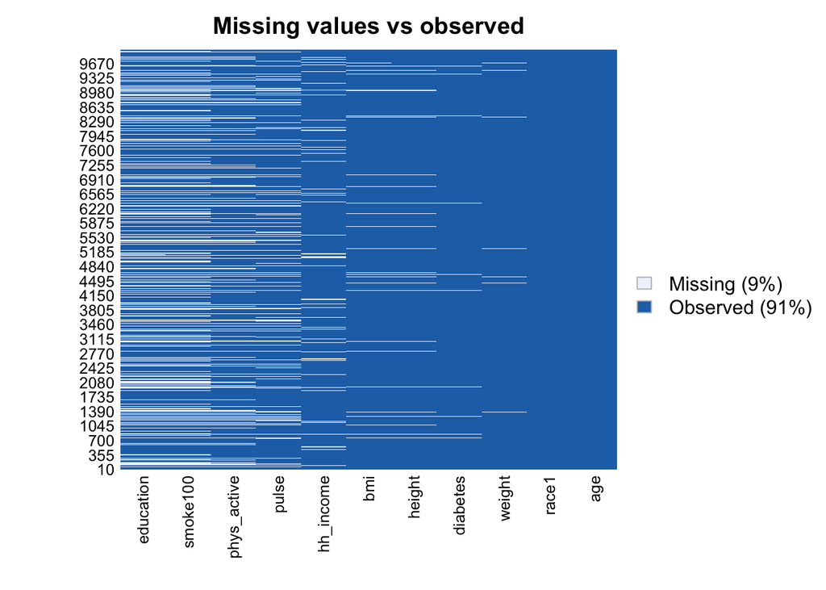

```r
nhanes <-
  NHANES %>%
  select("Age", "Race1", "Education", "HHIncome", "Weight", "Height", "Pulse",
         "Diabetes", "BMI", "PhysActive", "Smoke100") %>%
  janitor::clean_names()

missmap(nhanes, main = "Missing values vs observed") # easy and quick way to look at missing values
```

```r
nhanes <-
  nhanes %>%
  drop_na(diabetes) %>%
  na.omit() # 6,356 observations after dropping missing values


# checking if we need to center and scale

nhanes_numeric <- nhanes %>% dplyr::select(where(is.numeric))
nhanes_not_numeric <- nhanes %>% dplyr::select(!where(is.numeric))
correlations <- cor(nhanes_numeric, use="complete.obs")
high_correlations<-findCorrelation(correlations, cutoff=0.4)

colMeans(nhanes_numeric, na.rm=TRUE)
```

```
##       age    weight    height     pulse       bmi
##  47.12177  82.88288 169.14353  72.41315  28.88031
```

```r
apply(nhanes_numeric, 2, sd, na.rm=TRUE)
```

```
##       age    weight    height     pulse       bmi
## 16.819764 21.370731 10.036113 11.809763  6.709083
```

```r
#Centering and Scaling
set.up.preprocess <- preProcess(nhanes_numeric, method=c("center", "scale"))
#Output pre-processed values
transformed_vals<-predict(set.up.preprocess, nhanes_numeric)
nhanes_transformed <- bind_cols(transformed_vals, nhanes_not_numeric)

# checking the distribution of diabetes outcome

distribution_diabetes <-
  nhanes %>%
  group_by(diabetes) %>%
  summarise(count = n(),
            proportion = count/nrow(nhanes))

distribution_diabetes
```

```
## # A tibble: 2 x 3
##   diabetes count proportion
##   <fct>    <int>      <dbl>
## 1 No        5697      0.896
## 2 Yes        659      0.104
```

The outcome of interest `diabetes` had 142 NA values. After dropping these observations, there were 6356 observations left in the NHANES dataset.

We can also see that the means and standard deviations of the numeric variables are very different, therefore we will center and scale.

Checking the distribution of `diabetes`, we see that there is an imbalance where 89.63% of the observations do not have diabetes and the other 10.37% does have diabetes. When splitting the data, we need to keep the distribution of the outcome the same in both the training and testing datasets.

**Splitting the data.**

```r
set.seed(100)
train_indices <- createDataPartition(y=nhanes_transformed$diabetes, p=0.7, list=FALSE)
training <- nhanes_transformed[train_indices, ]
testing <- nhanes_transformed[-train_indices, ]

training %>% group_by(diabetes) %>% summarise(count = n(),
                                              proportion = count/nrow(training))
```

```
## # A tibble: 2 x 3
##   diabetes count proportion
##   <fct>    <int>      <dbl>
## 1 No        3988      0.896
## 2 Yes        462      0.104
```

```r
testing %>% group_by(diabetes) %>% summarise(count = n(),
                                             proportion = count/nrow(testing))
```

```
## # A tibble: 2 x 3
##   diabetes count proportion
##   <fct>    <int>      <dbl>
## 1 No        1709      0.897
## 2 Yes        197      0.103
```

# 1. Classification Tree.

```r
set.seed(100)
training_control <- trainControl(method="cv", number=10, sampling="down") # from caret
hyper_grid <- expand.grid(cp=seq(0.0001, 0.003, by=0.0001)) # choosing hyperparameter from grid method
tree_diabetes <- train(diabetes ~., data = training, method = "rpart",
                       trControl = training_control, tuneGrid = hyper_grid)
tree_diabetes$bestTune
```

```
##       cp
## 30 0.003
```

```r
varImp(tree_diabetes)
```

```
## rpart variable importance
##
##   only 20 most important variables shown (out of 33)
##
##                         Overall
## age                    100.0000
## bmi                     66.7518
## weight                  45.9515
## pulse                   35.0033
## height                  24.5217
## race1White              22.8623
## hh_incomemore 99999     14.3674
## educationSome College   10.9355
## phys_activeYes           9.6011
## smoke100Yes              6.5168
## hh_income35000-44999     3.3019
## race1Mexican             2.1967
## hh_income45000-54999     1.9195
## educationHigh School     1.5292
## hh_income 5000-9999      1.2968
## hh_income55000-64999     0.7185
## `hh_income45000-54999`   0.0000
## `hh_income25000-34999`   0.0000
## `hh_income20000-24999`   0.0000
## `hh_income65000-74999`   0.0000
```

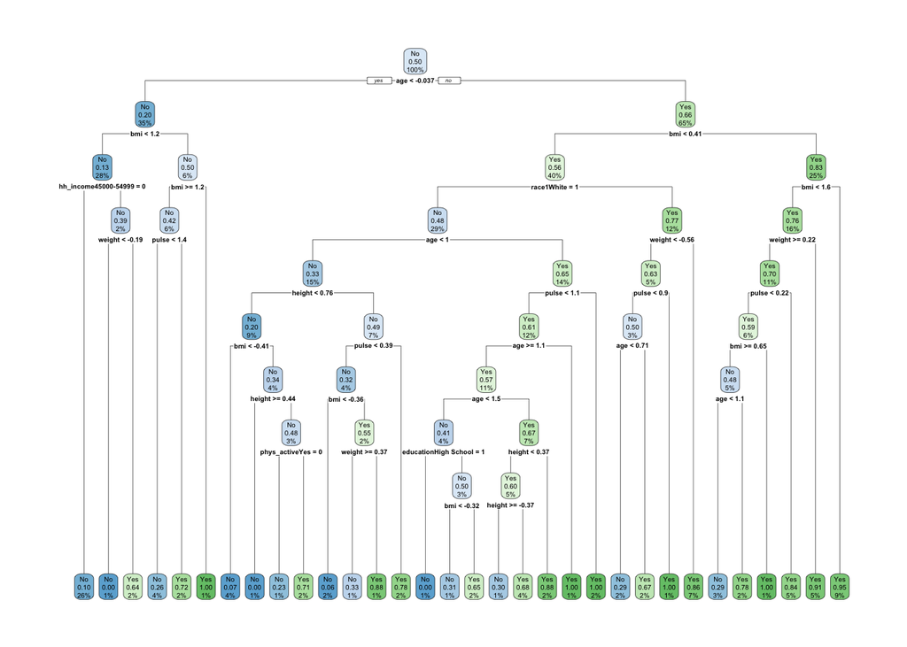

```r
rpart.plot(tree_diabetes$finalModel)
```

### Classification tree model results.

```r
# Making predictions
pred_diabetes <- predict(tree_diabetes, training)
pred_diabetes_probability <- predict(tree_diabetes, training, type="prob")

# Printing the confusion matrix
results <- confusionMatrix(pred_diabetes, training$diabetes, positive = "Yes")
print(results)
```

```
## Confusion Matrix and Statistics
##
##           Reference
## Prediction   No  Yes
##        No  2943   63
##        Yes 1045  399
##
##                Accuracy : 0.751
##                  95% CI : (0.738, 0.7637)
##     No Information Rate : 0.8962
##     P-Value [Acc > NIR] : 1
##
##                   Kappa : 0.3102
##
##  Mcnemar's Test P-Value : <2e-16
##
##             Sensitivity : 0.86364
##             Specificity : 0.73796
##          Pos Pred Value : 0.27632
##          Neg Pred Value : 0.97904
##              Prevalence : 0.10382
##          Detection Rate : 0.08966
##    Detection Prevalence : 0.32449
##       Balanced Accuracy : 0.80080
##
##        'Positive' Class : Yes
##
```

The classification tree uses a cross-validation optimal parameter of 0.003 and identifies `age`, `bmi`, and `weight` to be most important variables followed by `pulse`, `height`, and `race White`.

After applying our classification tree model to the training dataset, we find that it is 75.1% accurate in predicting diabetes status, with a sensitivity and specificity of 86.36% and 73.8%, respectively.

# 2. Support Vector Classifier.

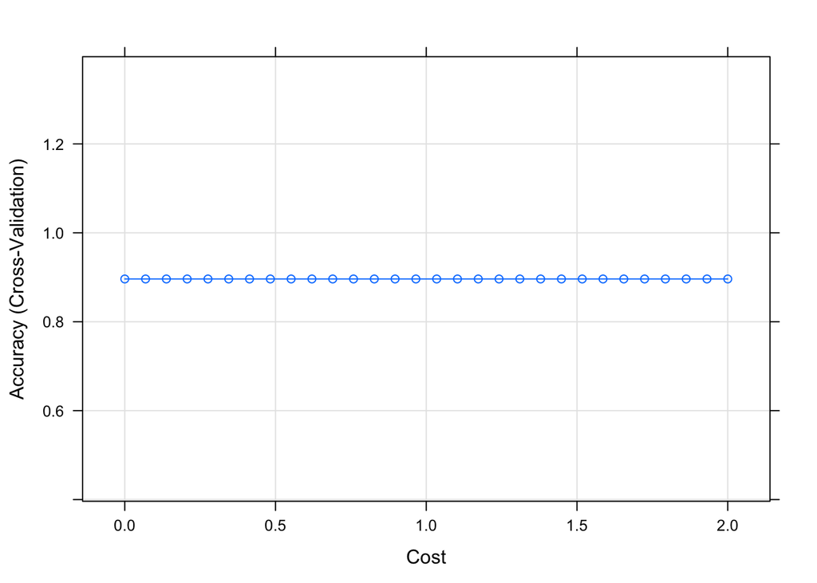

```r
set.seed(100)
train_control <- trainControl(method="cv", number = 10)#, sampling = "down")

svm_caret <- train(diabetes ~ ., data = training, method="svmLinear",
                   trControl=train_control, preProcess=c("center", "scale"),
                   tuneGrid=expand.grid(C = seq(0.00001,2, length=30)))

#svm_caret
plot(svm_caret)
```

### Support vector classifier results and predictions.

```r
svm_caret$finalModel
```

```
## Support Vector Machine object of class "ksvm"
##
## SV type: C-svc  (classification)
##  parameter : cost C = 1e-05
##
## Linear (vanilla) kernel function.
##
## Number of Support Vectors : 924
##
## Objective Function Value : -0.0092
## Training error : 0.10382
```

```r
# Making predictions
svm_training_pred <- predict(svm_caret, newdata = training)
table(svm_training_pred, training$diabetes)
```

```
##
## svm_training_pred   No  Yes
##               No  3988  462
##               Yes    0    0
```

```r
# Confusion matrix
confusion_svm <- confusionMatrix(svm_training_pred, training$diabetes, positive="Yes")
print(confusion_svm)
```

```
## Confusion Matrix and Statistics
##
##           Reference
## Prediction   No  Yes
##        No  3988  462
##        Yes    0    0
##
##                Accuracy : 0.8962
##                  95% CI : (0.8868, 0.905)
##     No Information Rate : 0.8962
##     P-Value [Acc > NIR] : 0.5124
##
##                   Kappa : 0
##
##  Mcnemar's Test P-Value : <2e-16
##
##             Sensitivity : 0.0000
##             Specificity : 1.0000
##          Pos Pred Value :    NaN
##          Neg Pred Value : 0.8962
##              Prevalence : 0.1038
##          Detection Rate : 0.0000
##    Detection Prevalence : 0.0000
##       Balanced Accuracy : 0.5000
##
##        'Positive' Class : Yes
##
```

The support vector machine uses a linear classifier and identifies the optimal hyperparameter for cost to be 10^{-5} and results in 924 support vectors.

After applying our support vector classifier to the training dataset, we find that it is 89.62% accurate in predicting diabetes status, with a sensitivity and specificity of 0% and 100%, respectively. The sensitivity is especially very low at 0%.

# 3. Logistic Regression.

```r
# Regularized logistic regression
set.seed(100)
train_control <- trainControl(method="cv", number = 10) #, sampling = "down")
logistic_reg <- train(diabetes ~., data = training,
                      method = "glmnet", family = "binomial",
                      trControl = train_control, tuneLength=10)
logistic_reg$bestTune
```

```
##    alpha      lambda
## 77   0.8 0.005862481
```

### Logistic regression results and predictions.

```r
# Coefficients for the regularized logistic regression
coef(logistic_reg$finalModel, logistic_reg$bestTune$lambda)
```

```
## 27 x 1 sparse Matrix of class "dgCMatrix"
##                                   1
## (Intercept)             -2.29050601
## age                      1.01699945
## weight                   0.14749911
## height                   .
## pulse                    0.07693452
## bmi                      0.43261493
## race1Hispanic           -0.02905864
## race1Mexican             0.11338748
## race1White              -0.54710502
## race1Other               0.10607248
## education9 - 11th Grade -0.08019115
## educationHigh School     .
## educationSome College    .
## educationCollege Grad    .
## hh_income 5000-9999      0.16303531
## hh_income10000-14999     0.11683894
## hh_income15000-19999     .
## hh_income20000-24999     0.25777206
## hh_income25000-34999     .
## hh_income35000-44999     .
## hh_income45000-54999     .
## hh_income55000-64999     0.01221825
## hh_income65000-74999    -0.02305878
## hh_income75000-99999     .
## hh_incomemore 99999     -0.09548825
## phys_activeYes          -0.10335533
## smoke100Yes              0.14098255
```

```r
# Making predictions
logistic_pred <- logistic_reg %>% predict(training)

# Confusion Matrix
confusion_logistic <-
  confusionMatrix(logistic_pred, training$diabetes,
                  positive="Yes")
confusion_logistic$table
```

```
##           Reference
## Prediction   No  Yes
##        No  3972  436
##        Yes   16   26
```

It is a good idea to use a regularized logistic regression because there are many features in the model, especially due to dummy variables for factor-level features. The cross-validation in the elastic net algorithm chooses the optimal alpha to be 0.8 and lambda to be 0.0058625.

Features that are minimized in this algorithm include `height`, `education` on the high school, college, and graduate levels, and `household income` on multiple levels. Features kept in the model include `age`, `weight`, `pulse`, `bmi`, all levels of `race`, `physical activity`, and `smoking status`.

After applying this regularized logistic regression model to the training dataset, we find that it is 89.84% accurate in predicting diabetes status, with a sensitivity and specificity of 5.63% and 99.6%, respectively. The sensitivity of this model is especially very low.

# Final Model.

My final model is the classification tree. Although it yields the lowest accuracy of the three models, it has the best trade-off between sensitivity and specificity.

```r
model <- c("Classification Tree", "Support Vector Classifier", "Regularized Logistic Regression")
accuracy <- c(results$overall[1], confusion_svm$overall[1], confusion_logistic$overall[1])
sensitivity <- c(results$byClass[1], confusion_svm$byClass[1], confusion_logistic$byClass[1])
specificity <- c(results$byClass[2], confusion_svm$byClass[2], confusion_logistic$byClass[2])

data.frame(model, accuracy, sensitivity, specificity)
```

```
##                             model  accuracy sensitivity specificity
## 1             Classification Tree 0.7510112  0.86363636   0.7379639
## 2       Support Vector Classifier 0.8961798  0.00000000   1.0000000
## 3 Regularized Logistic Regression 0.8984270  0.05627706   0.9959880
```

The classification tree is the most clinically meaningful algorithm because both the support vector classifier and regularized logistic regression have very low sensitivities. In the case when we want to identify those who truly have diabetes, it would be important to have high sensitivity so that patients can receive the correct diagnosis and adequate care.

```r
# Making predictions
pred_diabetes_test <- predict(tree_diabetes, testing)
pred_diabetes_prob_test <- predict(tree_diabetes, testing, type="prob")

# Printing the confusion matrix
results_test <- confusionMatrix(pred_diabetes_test, testing$diabetes, positive = "Yes")
print(results_test)
```

```
## Confusion Matrix and Statistics
##
##           Reference
## Prediction   No  Yes
##        No  1229   60
##        Yes  480  137
##
##                Accuracy : 0.7167
##                  95% CI : (0.6959, 0.7368)
##     No Information Rate : 0.8966
##     P-Value [Acc > NIR] : 1
##
##                   Kappa : 0.2134
##
##  Mcnemar's Test P-Value : <2e-16
##
##             Sensitivity : 0.69543
##             Specificity : 0.71913
##          Pos Pred Value : 0.22204
##          Neg Pred Value : 0.95345
##              Prevalence : 0.10336
##          Detection Rate : 0.07188
##    Detection Prevalence : 0.32371
##       Balanced Accuracy : 0.70728
##
##        'Positive' Class : Yes
##
```

### Limitations and Comments.

- One limitation of the classification tree is that it is unstable and highly sensitive to changes in data or features. As a result, when adding in more or different information in the training dataset, the classification tree would not be robust to these changes.
- Another limitation of the classification tree is that it treats variables with more values preferentially when making the splits. Therefore, continuous variables will generally be preferred in the algorithm over binary variables. We can also see this occur in the plot of the final model for splits using `pulse`, `bmi`, and `age`.